**Chapter 5: Exponential population growth**

[figure not shown]

## Objectives

This exercise describes and estimates population growth rates, and projection of abundance based on deterministic and stochastic growth rates.

## Consequences of stochastic population growth

One non-intuitive idea that emerged from Chapter 5 in the text is that (under many conditions) the average growth rate of a population might be much higher than the most likely population trajectory. That is, when conditions are variable, population dynamics are governed not by the arithmetic mean, but rather by the geometric mean. Let’s see how that plays out.

Suppose a sage grouse population abundance was at 50 individuals in year 2020 and 65 individuals in year 2021. We can calculate the geometric growth rate $\lambda$ and the exponential growth rate $\rho$ as:

```r
N1 <- 50
N2 <- 65

lambda <- N2/N1  # geometric growth rate
rho <- log(lambda) # exponential growth rate

print(lambda)
print(rho)
```

[output not shown]

If managers have monitored the sage grouse population over 10 years, we can use the time-series to calculate the annual growth rate $\lambda_y$.

```r
year <- 2012:2021
abundance <- c(52, 43, 90, 125, 72, 128, 97, 50, 50, 65)

sg_data <- data.frame(matrix(nrow = length(year), ncol = 3))
colnames(sg_data) <- c("year", "abundance", "lambda_y")

sg_data$year <- year
sg_data$abundance <- abundance

for(i in 1:length(sg_data$year)) {
  sg_data$lambda_y[i] <- sg_data$abundance[i + 1] / sg_data$abundance[i]
}

print(sg_data)
```

```
##    year abundance  lambda_y
## 1  2012        52 0.8269231
## 2  2013        43 2.0930233
## 3  2014        90 1.3888889
## 4  2015       125 0.5760000
## 5  2016        72 1.7777778
## 6  2017       128 0.7578125
## 7  2018        97 0.5154639
## 8  2019        50 1.0000000
## 9  2020        50 1.3000000
## 10 2021        65        NA
```

Now, to calculate the average annual growth rate we need to understand the difference between the arithmetic mean $\lambda_a$ vs the geometric mean $\lambda_g$. We calculated $\rho$ above based on $\lambda_g$, but what it means is a constant fraction or proportion of the current population is added to or subtracted from the population continuously or instantaneously. The geometric growth means a constant fraction or proportion of the current population is added to or subtracted from the population at each discrete time step. Finally, the arithmetic Growth means a constant number of individuals is added to or subtracted from the population at each time step, regardless of the current population size.

```r
#Arithmetic mean
lambda_a <- mean(sg_data$lambda_y, na.rm = TRUE)

#Geometric Mean
lambda_g <- prod(sg_data$lambda_y, na.rm = TRUE) ^ (1 / length(sg_data$lambda_y))
```

With a known growth rate, projection of abundance is done based on: $N_{t+1}$ = $N_{t}$ $\lambda$ or equally based on: $N_{t}$ = $N_{1}$ $\lambda^t$. If we project abundance of the grouse population based on these two calculated growth averages, we get different numbers. You noticed that $\lambda_y$ for the year 2021 was NA, and the abundance for this year was 65. Which of the two growth rate averages leads to this abundance for the year 2021? As you see below, $\lambda_g$ describes the most likely future trajectory of a population with stochastic growth. Overall, $\lambda_g$ is smaller than $\lambda_a$ whenever $\lambda_y$ varies across the years.

```r
print(lambda_a)
print(lambda_g)

#Projected N
sg_data$abundance[1] * (lambda_a ^ length(year))
sg_data$abundance[1] * (lambda_g ^ length(year))
```

[output not shown]

## Estimating exponential trend

**Practice:**

```r
year <- 2020:2027

sg_data <- data.frame(matrix(nrow = length(year), ncol = 5))
colnames(sg_data) <- c("year", "N_a", "N_b", "lambda", "lambda_y")

sg_data$year <- year
sg_data$N_a[1] <- sg_data$N_b[1] <- 50
sg_data$lambda <- 1.05
sg_data$lambda_y <- rep(c(1.05, 0.55), length.out = length(sg_data$lambda_y), )

#Projected N
for(i in 2 : length(sg_data$year)) {
  sg_data$N_a [i] <- sg_data$N_a [i - 1] * sg_data$lambda[i - 1]
  sg_data$N_b [i] <- sg_data$N_b [i - 1] * sg_data$lambda_y[i - 1]

}

print(sg_data)
```

```
##   year      N_a       N_b lambda lambda_y
## 1 2020 50.00000 50.000000   1.05     1.05
## 2 2021 52.50000 52.500000   1.05     0.55
## 3 2022 55.12500 28.875000   1.05     1.05
## 4 2023 57.88125 30.318750   1.05     0.55
## 5 2024 60.77531 16.675313   1.05     1.05
## 6 2025 63.81408 17.509078   1.05     0.55
## 7 2026 67.00478  9.629993   1.05     1.05
## 8 2027 70.35502 10.111493   1.05     0.55
```

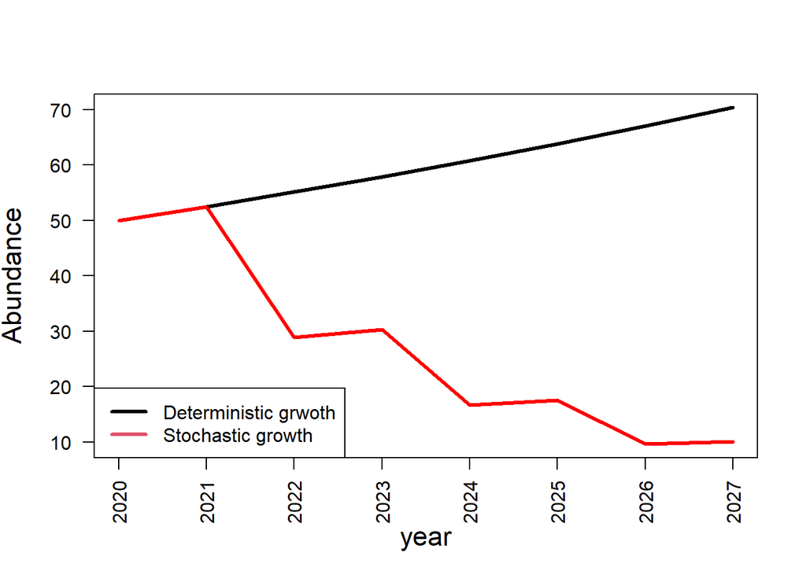

```r
plot(x     = sg_data$year,
     y     = sg_data$N_a,
     col   = "black",
     type  = "l",
     lwd   = 3,
     las   = 2,
     cex.lab = 1.4,
     ylim  = c(min(sg_data$N_b), max(sg_data$N_a)),
     xlab  = "year",
     ylab  = "Abundance",
     )

points(x    = sg_data$year,
       y    = sg_data$N_b,
       col  = "red",
       lwd  = 3,
       type = "l")
legend("bottomleft",
       c("Deterministic grwoth",
         "Stochastic growth"),
       col = 1:2, lty = 1, lwd = 3)
```